# Group 5

### HW 2

### Grayson Felt, Hayden Clegg, Beau Denhalter

```python
import numpy as np
import pandas as pd
import matplotlib.pyplot as plt
import seaborn as sns
import os as os
```

```python
df = pd.read_csv('nyc-rolling-sales.csv')
df
```

|  | Unnamed: 0 | BOROUGH | NEIGHBORHOOD | BUILDING CLASS CATEGORY | TAX CLASS AT PRESENT | BLOCK | LOT | EASE-MENT | BUILDING CLASS AT PRESENT | ADDRESS | ... | RESIDENTIAL UNITS | COMMERCIAL UNITS | TOTAL UNITS | LAND SQUARE FEET | GROSS SQUARE FEET | YEAR BUILT | TAX CLASS AT TIME OF SALE | BUILDING CLASS AT TIME OF SALE | SALE PRICE | SALE DATE |
| --- | --- | --- | --- | --- | --- | --- | --- | --- | --- | --- | --- | --- | --- | --- | --- | --- | --- | --- | --- | --- | --- |
| 0 | 4 | 1 | ALPHABET CITY | 07 RENTALS - WALKUP APARTMENTS | 2A | 392 | 6 |  | C2 | 153 AVENUE B | ... | 5 | 0 | 5 | 1633 | 6440 | 1900 | 2 | C2 | 6625000 | 2017-07-19 00:00:00 |
| 1 | 5 | 1 | ALPHABET CITY | 07 RENTALS - WALKUP APARTMENTS | 2 | 399 | 26 |  | C7 | 234 EAST 4TH STREET | ... | 28 | 3 | 31 | 4616 | 18690 | 1900 | 2 | C7 | - | 2016-12-14 00:00:00 |
| 2 | 6 | 1 | ALPHABET CITY | 07 RENTALS - WALKUP APARTMENTS | 2 | 399 | 39 |  | C7 | 197 EAST 3RD STREET | ... | 16 | 1 | 17 | 2212 | 7803 | 1900 | 2 | C7 | - | 2016-12-09 00:00:00 |
| 3 | 7 | 1 | ALPHABET CITY | 07 RENTALS - WALKUP APARTMENTS | 2B | 402 | 21 |  | C4 | 154 EAST 7TH STREET | ... | 10 | 0 | 10 | 2272 | 6794 | 1913 | 2 | C4 | 3936272 | 2016-09-23 00:00:00 |
| 4 | 8 | 1 | ALPHABET CITY | 07 RENTALS - WALKUP APARTMENTS | 2A | 404 | 55 |  | C2 | 301 EAST 10TH STREET | ... | 6 | 0 | 6 | 2369 | 4615 | 1900 | 2 | C2 | 8000000 | 2016-11-17 00:00:00 |
| ... | ... | ... | ... | ... | ... | ... | ... | ... | ... | ... | ... | ... | ... | ... | ... | ... | ... | ... | ... | ... | ... |
| 84543 | 8409 | 5 | WOODROW | 02 TWO FAMILY DWELLINGS | 1 | 7349 | 34 |  | B9 | 37 QUAIL LANE | ... | 2 | 0 | 2 | 2400 | 2575 | 1998 | 1 | B9 | 450000 | 2016-11-28 00:00:00 |
| 84544 | 8410 | 5 | WOODROW | 02 TWO FAMILY DWELLINGS | 1 | 7349 | 78 |  | B9 | 32 PHEASANT LANE | ... | 2 | 0 | 2 | 2498 | 2377 | 1998 | 1 | B9 | 550000 | 2017-04-21 00:00:00 |
| 84545 | 8411 | 5 | WOODROW | 02 TWO FAMILY DWELLINGS | 1 | 7351 | 60 |  | B2 | 49 PITNEY AVENUE | ... | 2 | 0 | 2 | 4000 | 1496 | 1925 | 1 | B2 | 460000 | 2017-07-05 00:00:00 |
| 84546 | 8412 | 5 | WOODROW | 22 STORE BUILDINGS | 4 | 7100 | 28 |  | K6 | 2730 ARTHUR KILL ROAD | ... | 0 | 7 | 7 | 208033 | 64117 | 2001 | 4 | K6 | 11693337 | 2016-12-21 00:00:00 |
| 84547 | 8413 | 5 | WOODROW | 35 INDOOR PUBLIC AND CULTURAL FACILITIES | 4 | 7105 | 679 |  | P9 | 155 CLAY PIT ROAD | ... | 0 | 1 | 1 | 10796 | 2400 | 2006 | 4 | P9 | 69300 | 2016-10-27 00:00:00 |

84548 rows × 22 columns

```python
sum(df.duplicated())
df = df.drop_duplicates(df.columns, keep='last')
```

Instead of '0's, the data seems to consist of '-', we should replace those now

```python
df.replace({"-":0},inplace=True)
```

We should also replace the blank observations with null values

```python
df.replace(' ',np.nan, inplace=True)
```

```python
df.info()
```

```
<class 'pandas.core.frame.DataFrame'>
Int64Index: 84548 entries, 0 to 84547
Data columns (total 22 columns):
 #   Column                          Non-Null Count  Dtype
---  ------                          --------------  -----
 0   Unnamed: 0                      84548 non-null  int64
 1   BOROUGH                         84548 non-null  int64
 2   NEIGHBORHOOD                    84548 non-null  object
 3   BUILDING CLASS CATEGORY         84548 non-null  object
 4   TAX CLASS AT PRESENT            83810 non-null  object
 5   BLOCK                           84548 non-null  int64
 6   LOT                             84548 non-null  int64
 7   EASE-MENT                       0 non-null      float64
 8   BUILDING CLASS AT PRESENT       83810 non-null  object
 9   ADDRESS                         84548 non-null  object
 10  APARTMENT NUMBER                19052 non-null  object
 11  ZIP CODE                        84548 non-null  int64
 12  RESIDENTIAL UNITS               84548 non-null  int64
 13  COMMERCIAL UNITS                84548 non-null  int64
 14  TOTAL UNITS                     84548 non-null  int64
 15  LAND SQUARE FEET                84548 non-null  object
 16  GROSS SQUARE FEET               84548 non-null  object
 17  YEAR BUILT                      84548 non-null  int64
 18  TAX CLASS AT TIME OF SALE       84548 non-null  int64
 19  BUILDING CLASS AT TIME OF SALE  84548 non-null  object
 20  SALE PRICE                      84548 non-null  object
 21  SALE DATE                       84548 non-null  object
dtypes: float64(1), int64(10), object(11)
memory usage: 14.8+ MB
```

First, we can change SALE DATE to a datetime variable and extract both the month/year into two different variables

```python
df['SALE DATE']= pd.to_datetime(df['SALE DATE'], errors='coerce')
df['SALE MONTH'] = pd.DatetimeIndex(df['SALE DATE']).month.astype("category")
df['SALE YEAR'] = pd.DatetimeIndex(df['SALE DATE']).year.astype("category")
del df['SALE DATE']
```

```python
df.columns
```

```
Index(['Unnamed: 0', 'BOROUGH', 'NEIGHBORHOOD', 'BUILDING CLASS CATEGORY',
       'TAX CLASS AT PRESENT', 'BLOCK', 'LOT', 'EASE-MENT',
       'BUILDING CLASS AT PRESENT', 'ADDRESS', 'APARTMENT NUMBER', 'ZIP CODE',
       'RESIDENTIAL UNITS', 'COMMERCIAL UNITS', 'TOTAL UNITS',
       'LAND SQUARE FEET', 'GROSS SQUARE FEET', 'YEAR BUILT',
       'TAX CLASS AT TIME OF SALE', 'BUILDING CLASS AT TIME OF SALE',
       'SALE PRICE', 'SALE MONTH', 'SALE YEAR'],
      dtype='object')
```

```python
for col in df.columns:
    print(col, df[col].nunique())
```

```
Unnamed: 0 26736
BOROUGH 5
NEIGHBORHOOD 254
BUILDING CLASS CATEGORY 47
TAX CLASS AT PRESENT 10
BLOCK 11566
LOT 2627
EASE-MENT 0
BUILDING CLASS AT PRESENT 166
ADDRESS 67563
APARTMENT NUMBER 3988
ZIP CODE 186
RESIDENTIAL UNITS 176
COMMERCIAL UNITS 55
TOTAL UNITS 192
LAND SQUARE FEET 6062
GROSS SQUARE FEET 5691
YEAR BUILT 158
TAX CLASS AT TIME OF SALE 4
BUILDING CLASS AT TIME OF SALE 166
SALE PRICE 10008
SALE MONTH 12
SALE YEAR 2
```

```python
for col in ['BOROUGH', 'TAX CLASS AT PRESENT', 'EASE-MENT', 'TAX CLASS AT TIME OF SALE']:
    print(df[col].value_counts())
```

```
4    26736
3    24047
1    18306
5     8410
2     7049
Name: BOROUGH, dtype: int64
1     38633
2     30919
4      6140
2A     2521
2C     1915
1A     1444
1B     1234
2B      814
1C      186
3         4
Name: TAX CLASS AT PRESENT, dtype: int64
Series([], Name: EASE-MENT, dtype: int64)
1    41533
2    36726
4     6285
3        4
Name: TAX CLASS AT TIME OF SALE, dtype: int64
```

'BOROUGH' consists of 5 distinct categories so this should be converted to categorical 'NEIGHBORHOOD', 'BUILDING CLASS CATEGORY', 'TAX CLASS AT PRESENT', 'ZIP CODE', 'YEAR BUILT', 'TAX CLASS AT TIME OF SALE', 'BUILDING CLASS AT TIME OF SALE', 'BUILDING CLASS AT PRESENT' all represent data that can be bundled into distinct categories and therefore should all be converted to categorical data types

```python
categoricals = ['BOROUGH', 'NEIGHBORHOOD', 'BUILDING CLASS CATEGORY', 'TAX CLASS AT PRESENT',
                'ZIP CODE', 'YEAR BUILT', 'TAX CLASS AT TIME OF SALE', 'BUILDING CLASS AT TIME OF SALE',
                'BUILDING CLASS AT PRESENT']
```

```python
for col in categoricals:
    df[col] = df[col].astype('category')
```

'SALE PRICE' should not be considered an object and instead be considered a float64

Same goes for 'LAND SQUARE FEET' and 'GROSS SQUARE FEET'

```python
float64s = ['SALE PRICE', 'LAND SQUARE FEET', 'GROSS SQUARE FEET']
```

```python
for col in float64s:
    df[col]=pd.to_numeric(df[col], errors='coerce')
```

```python
df.info()
```

```
<class 'pandas.core.frame.DataFrame'>
Int64Index: 84548 entries, 0 to 84547
Data columns (total 23 columns):
 #   Column                          Non-Null Count  Dtype
---  ------                          --------------  -----
 0   Unnamed: 0                      84548 non-null  int64
 1   BOROUGH                         84548 non-null  category
 2   NEIGHBORHOOD                    84548 non-null  category
 3   BUILDING CLASS CATEGORY         84548 non-null  category
 4   TAX CLASS AT PRESENT            83810 non-null  category
 5   BLOCK                           84548 non-null  int64
 6   LOT                             84548 non-null  int64
 7   EASE-MENT                       0 non-null      float64
 8   BUILDING CLASS AT PRESENT       83810 non-null  category
 9   ADDRESS                         84548 non-null  object
 10  APARTMENT NUMBER                19052 non-null  object
 11  ZIP CODE                        84548 non-null  category
 12  RESIDENTIAL UNITS               84548 non-null  int64
 13  COMMERCIAL UNITS                84548 non-null  int64
 14  TOTAL UNITS                     84548 non-null  int64
 15  LAND SQUARE FEET                58296 non-null  float64
 16  GROSS SQUARE FEET               56936 non-null  float64
 17  YEAR BUILT                      84548 non-null  category
 18  TAX CLASS AT TIME OF SALE       84548 non-null  category
 19  BUILDING CLASS AT TIME OF SALE  84548 non-null  category
 20  SALE PRICE                      69987 non-null  float64
 21  SALE MONTH                      84548 non-null  category
 22  SALE YEAR                       84548 non-null  category
dtypes: category(11), float64(4), int64(6), object(2)
memory usage: 9.7+ MB
```

'Unnamed: 0' is an iterator and is not useful to this dataset so it should be dropped

'EASE-MENT' is blank and should be dropped

```python
df.drop(labels=['Unnamed: 0','EASE-MENT'], axis=1, inplace=True)
```

```python
df.describe(include='all').T
```

|  | count | unique | top | freq | mean | std | min | 25% | 50% | 75% | max |
| --- | --- | --- | --- | --- | --- | --- | --- | --- | --- | --- | --- |
| BOROUGH | 84548 | 5 | 4 | 26736 | NaN | NaN | NaN | NaN | NaN | NaN | NaN |
| NEIGHBORHOOD | 84548 | 254 | FLUSHING-NORTH | 3068 | NaN | NaN | NaN | NaN | NaN | NaN | NaN |
| BUILDING CLASS CATEGORY | 84548 | 47 | 01 ONE FAMILY DWELLINGS | 18235 | NaN | NaN | NaN | NaN | NaN | NaN | NaN |
| TAX CLASS AT PRESENT | 83810 | 10 | 1 | 38633 | NaN | NaN | NaN | NaN | NaN | NaN | NaN |
| BLOCK | 84548 | NaN | NaN | NaN | 4237.22 | 3568.26 | 1 | 1322.75 | 3311 | 6281 | 16322 |
| LOT | 84548 | NaN | NaN | NaN | 376.224 | 658.137 | 1 | 22 | 50 | 1001 | 9106 |
| BUILDING CLASS AT PRESENT | 83810 | 166 | D4 | 12663 | NaN | NaN | NaN | NaN | NaN | NaN | NaN |
| ADDRESS | 84548 | 67563 | 131-05 40TH ROAD | 210 | NaN | NaN | NaN | NaN | NaN | NaN | NaN |
| APARTMENT NUMBER | 19052 | 3988 | 4 | 298 | NaN | NaN | NaN | NaN | NaN | NaN | NaN |
| ZIP CODE | 84548 | 186 | 10314 | 1687 | NaN | NaN | NaN | NaN | NaN | NaN | NaN |
| RESIDENTIAL UNITS | 84548 | NaN | NaN | NaN | 2.02526 | 16.721 | 0 | 0 | 1 | 2 | 1844 |
| COMMERCIAL UNITS | 84548 | NaN | NaN | NaN | 0.193559 | 8.71318 | 0 | 0 | 0 | 0 | 2261 |
| TOTAL UNITS | 84548 | NaN | NaN | NaN | 2.24918 | 18.9726 | 0 | 1 | 1 | 2 | 2261 |
| LAND SQUARE FEET | 58296 | NaN | NaN | NaN | 3941.68 | 41984 | 0 | 1650 | 2325 | 3500 | 4.25233e+06 |
| GROSS SQUARE FEET | 56936 | NaN | NaN | NaN | 4045.71 | 35032.5 | 0 | 1046.75 | 1680 | 2560 | 3.75056e+06 |
| YEAR BUILT | 84548 | 158 | 0 | 6970 | NaN | NaN | NaN | NaN | NaN | NaN | NaN |
| TAX CLASS AT TIME OF SALE | 84548 | 4 | 1 | 41533 | NaN | NaN | NaN | NaN | NaN | NaN | NaN |
| BUILDING CLASS AT TIME OF SALE | 84548 | 166 | R4 | 12989 | NaN | NaN | NaN | NaN | NaN | NaN | NaN |
| SALE PRICE | 69987 | NaN | NaN | NaN | 1.27646e+06 | 1.14053e+07 | 0 | 225000 | 530000 | 950000 | 2.21e+09 |
| SALE MONTH | 84548 | 12 | 6 | 8293 | NaN | NaN | NaN | NaN | NaN | NaN | NaN |
| SALE YEAR | 84548 | 2 | 2017 | 55055 | NaN | NaN | NaN | NaN | NaN | NaN | NaN |

```python
null_pct = df.isnull().sum() / len(df)
```

```python
null_pct = null_pct[null_pct>0]
null_pct
```

```
TAX CLASS AT PRESENT         0.008729
BUILDING CLASS AT PRESENT    0.008729
APARTMENT NUMBER             0.774661
LAND SQUARE FEET             0.310498
GROSS SQUARE FEET            0.326584
SALE PRICE                   0.172222
dtype: float64
```

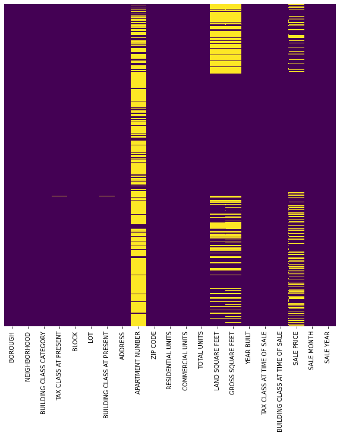

```python
plt.figure(figsize=(10,10))
sns.heatmap(df.isnull(),yticklabels=False,cbar=False,cmap='viridis')
plt.show()
```

Note: I am not replacing values just yet as there are observations that we need to remove to normalize the distributions. Replacing NA values with their current median would be innacurate.

```python
df.drop_duplicates(inplace=True)
```

```python
df.head()
```

|  | BOROUGH | NEIGHBORHOOD | BUILDING CLASS CATEGORY | TAX CLASS AT PRESENT | BLOCK | LOT | BUILDING CLASS AT PRESENT | ADDRESS | APARTMENT NUMBER | ZIP CODE | ... | COMMERCIAL UNITS | TOTAL UNITS | LAND SQUARE FEET | GROSS SQUARE FEET | YEAR BUILT | TAX CLASS AT TIME OF SALE | BUILDING CLASS AT TIME OF SALE | SALE PRICE | SALE MONTH | SALE YEAR |
| --- | --- | --- | --- | --- | --- | --- | --- | --- | --- | --- | --- | --- | --- | --- | --- | --- | --- | --- | --- | --- | --- |
| 0 | 1 | ALPHABET CITY | 07 RENTALS - WALKUP APARTMENTS | 2A | 392 | 6 | C2 | 153 AVENUE B | NaN | 10009 | ... | 0 | 5 | 1633.0 | 6440.0 | 1900 | 2 | C2 | 6625000.0 | 7 | 2017 |
| 1 | 1 | ALPHABET CITY | 07 RENTALS - WALKUP APARTMENTS | 2 | 399 | 26 | C7 | 234 EAST 4TH STREET | NaN | 10009 | ... | 3 | 31 | 4616.0 | 18690.0 | 1900 | 2 | C7 | NaN | 12 | 2016 |
| 2 | 1 | ALPHABET CITY | 07 RENTALS - WALKUP APARTMENTS | 2 | 399 | 39 | C7 | 197 EAST 3RD STREET | NaN | 10009 | ... | 1 | 17 | 2212.0 | 7803.0 | 1900 | 2 | C7 | NaN | 12 | 2016 |
| 3 | 1 | ALPHABET CITY | 07 RENTALS - WALKUP APARTMENTS | 2B | 402 | 21 | C4 | 154 EAST 7TH STREET | NaN | 10009 | ... | 0 | 10 | 2272.0 | 6794.0 | 1913 | 2 | C4 | 3936272.0 | 9 | 2016 |
| 4 | 1 | ALPHABET CITY | 07 RENTALS - WALKUP APARTMENTS | 2A | 404 | 55 | C2 | 301 EAST 10TH STREET | NaN | 10009 | ... | 0 | 6 | 2369.0 | 4615.0 | 1900 | 2 | C2 | 8000000.0 | 11 | 2016 |

5 rows × 21 columns

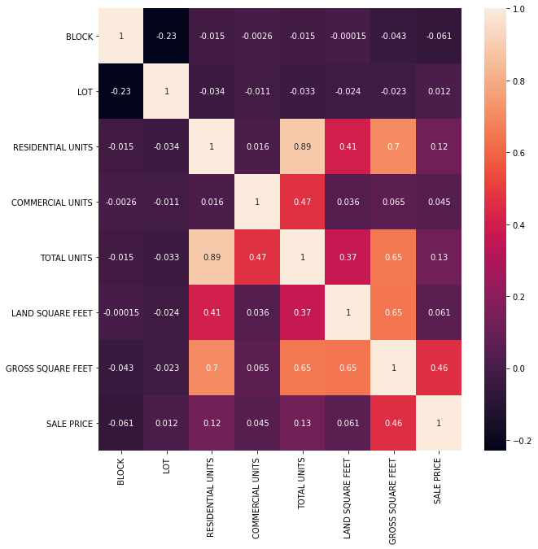

```python
plt.figure(figsize=(10,10))
sns.heatmap(df.corr(), annot=True)
plt.show()
```

```python
df['SALE PRICE'].describe()
```

```
count    6.953000e+04
mean     1.282107e+06
std      1.143661e+07
min      0.000000e+00
25%      2.300000e+05
50%      5.346955e+05
75%      9.500000e+05
max      2.210000e+09
Name: SALE PRICE, dtype: float64
```

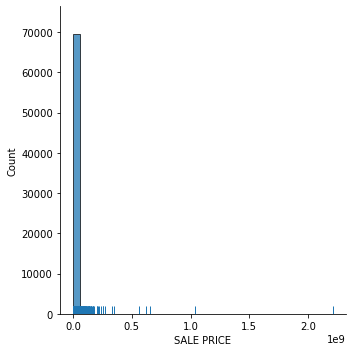

```python
plt.figure(figsize=(12,5))
sns.displot(df['SALE PRICE'], bins=40, rug=True)
plt.show()
```

There are an incredible amount of small ($0) observations here that need to be removed as they are not useful to this dataset

```python
df2 = df[(df['SALE PRICE'] > 10000) & (df['SALE PRICE'] < 10000000)]
```

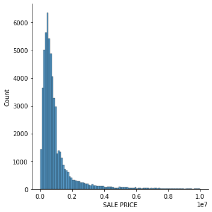

```python
sns.displot(df2['SALE PRICE'], bins=100)
```

```python
df2['SALE PRICE'].describe()
```

```
count    5.729900e+04
mean     9.931855e+05
std      1.213246e+06
min      1.000100e+04
25%      3.850000e+05
50%      6.300000e+05
75%      1.043353e+06
max      9.999999e+06
Name: SALE PRICE, dtype: float64
```

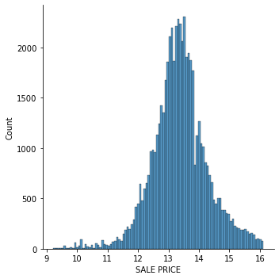

```python
norm_sale = np.log(df2['SALE PRICE'])
sns.displot(norm_sale, bins=100)
```

```python
print(norm_sale.skew())
```

```
-0.07516382562488344
```

'SALE PRICE' is now normalized Now we need to consider 'GROSS SQUARE FEET' and 'LAND SQUARE FEET', the two columns that I modified NA values

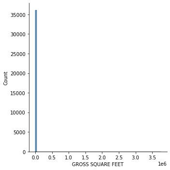

```python
sns.displot(df2['GROSS SQUARE FEET'], bins=80)
```

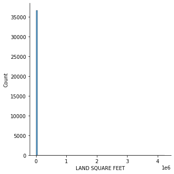

```python
sns.displot(df2['LAND SQUARE FEET'], bins=100)
```

They both suffer from being incredibly unnormalized

```python
df2['LAND SQUARE FEET'].describe()
```

```
count    3.668700e+04
mean     3.100068e+03
std      3.233332e+04
min      0.000000e+00
25%      1.350000e+03
50%      2.200000e+03
75%      3.200000e+03
max      4.228300e+06
Name: LAND SQUARE FEET, dtype: float64
```

```python
df2['GROSS SQUARE FEET'].describe()
```

```
count    3.619300e+04
mean     2.417306e+03
std      2.299432e+04
min      0.000000e+00
25%      8.400000e+02
50%      1.530000e+03
75%      2.288000e+03
max      3.750565e+06
Name: GROSS SQUARE FEET, dtype: float64
```

```python
df3 = df2[(df2['GROSS SQUARE FEET'] < 8000) & (df2['LAND SQUARE FEET'] < 8000)]
```

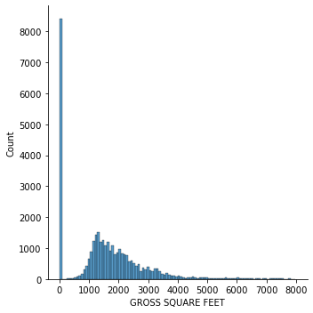

```python
sns.displot(df3['GROSS SQUARE FEET'], bins=100)
```

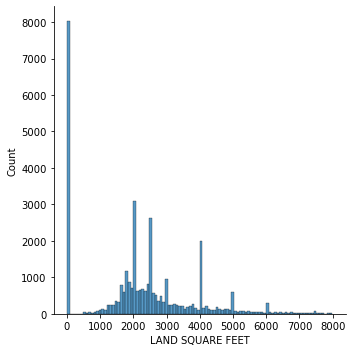

```python
sns.displot(df3['LAND SQUARE FEET'], bins=100)
```

Now, we can fill these NA values for 'SALE PRICE', 'LAND SQUARE FEET', and 'GROSS SQUARE FEET'

```python
df3['LAND SQUARE FEET'] = df3['LAND SQUARE FEET'].fillna(df3['LAND SQUARE FEET'].median())
df3['GROSS SQUARE FEET'] = df3['GROSS SQUARE FEET'].fillna(df3['GROSS SQUARE FEET'].median())
df3['SALE PRICE'] = df3['SALE PRICE'].fillna(df3['SALE PRICE'].median())
```

Now looking at 'YEAR BUILT'

```python
df3['YEAR BUILT'].value_counts()
```

```
1920    3369
1930    2698
1925    2555
1910    1739
0       1685
        ...
1892       0
1888       0
1883       0
1850       0
1894       0
Name: YEAR BUILT, Length: 158, dtype: int64
```

We should not include any values that have 'YEAR BUILT' = 0

```python
df4 = df3[df3['YEAR BUILT']!=0]
```

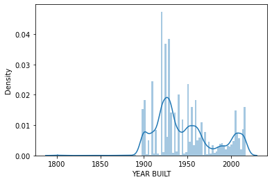

```python
sns.distplot(df4['YEAR BUILT'], bins=100)
```

Next, 'TOTAL UNITS'

```python
df4['TOTAL UNITS'].describe()
```

```
count    33070.000000
mean         1.651225
std         12.494207
min          0.000000
25%          1.000000
50%          1.000000
75%          2.000000
max       2261.000000
Name: TOTAL UNITS, dtype: float64
```

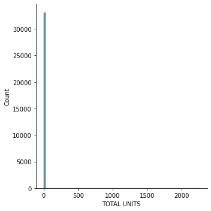

```python
sns.displot(df4['TOTAL UNITS'], bins=100)
```

```python
df5 = df4[(df4['TOTAL UNITS'] > 0) & (df4['TOTAL UNITS'] != 2261)]
```

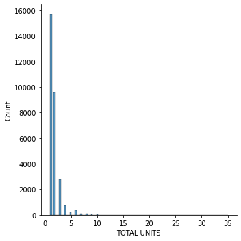

```python
sns.displot(df5['TOTAL UNITS'], bins=100)
```

Now to remove the two columns that contain sensitive information and are not useful

```python
del df5['ADDRESS']
del df5['APARTMENT NUMBER']
```

```python
df5.info()
```

```
<class 'pandas.core.frame.DataFrame'>
Int64Index: 29654 entries, 0 to 84545
Data columns (total 19 columns):
 #   Column                          Non-Null Count  Dtype
---  ------                          --------------  -----
 0   BOROUGH                         29654 non-null  category
 1   NEIGHBORHOOD                    29654 non-null  category
 2   BUILDING CLASS CATEGORY         29654 non-null  category
 3   TAX CLASS AT PRESENT            29654 non-null  category
 4   BLOCK                           29654 non-null  int64
 5   LOT                             29654 non-null  int64
 6   BUILDING CLASS AT PRESENT       29654 non-null  category
 7   ZIP CODE                        29654 non-null  category
 8   RESIDENTIAL UNITS               29654 non-null  int64
 9   COMMERCIAL UNITS                29654 non-null  int64
 10  TOTAL UNITS                     29654 non-null  int64
 11  LAND SQUARE FEET                29654 non-null  float64
 12  GROSS SQUARE FEET               29654 non-null  float64
 13  YEAR BUILT                      29654 non-null  category
 14  TAX CLASS AT TIME OF SALE       29654 non-null  category
 15  BUILDING CLASS AT TIME OF SALE  29654 non-null  category
 16  SALE PRICE                      29654 non-null  float64
 17  SALE MONTH                      29654 non-null  category
 18  SALE YEAR                       29654 non-null  category
dtypes: category(11), float64(3), int64(5)
memory usage: 2.5 MB
```

```python
df5.to_csv('nyc-rolling-sales-clean.csv')
```

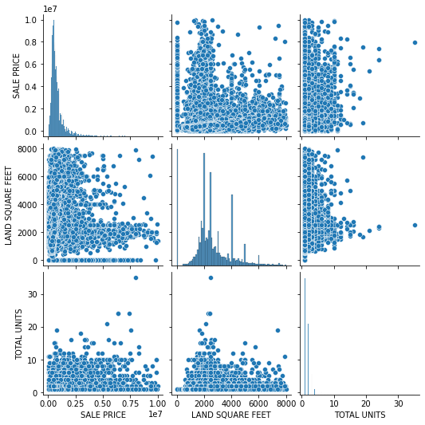

```python
sns.pairplot(df5[['SALE PRICE','LAND SQUARE FEET', 'TOTAL UNITS']])
```

'SALE PRICE' and 'LAND SQUARE FEET' are right skewed with 'LAND SQUARE FEET' having many outliars. 'TOTAL UNITS; does not have a normal distribution with very little variance in observations.

The distribution of observations between 'LAND SQUARE FEET' and 'SALE PRICE' combined with the insight from the correlation matrix shows that there is not a significant impact of 'LAND SQUARE FEET' on predicting sale price.

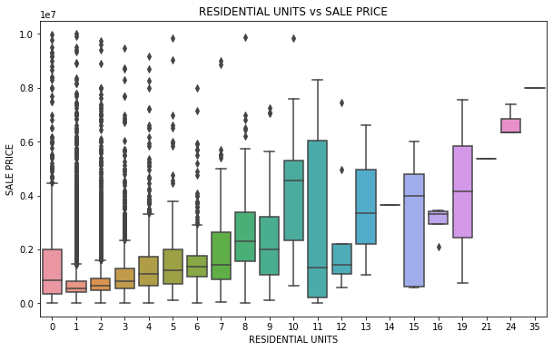

```python
plt.figure(figsize=(10,6))
sns.boxplot(x='RESIDENTIAL UNITS', y='SALE PRICE', data=df5)
plt.title('RESIDENTIAL UNITS vs SALE PRICE')
plt.show()
```

[figure not shown]

```python
plt.figure(figsize=(10,6))
sns.boxplot(x='BOROUGH', y='SALE PRICE', data=df5)
plt.title('RESIDENTIAL UNITS vs SALE PRICE')
plt.show()
```

From this figure, there is a much wider distribution of sale prices in borough 1 compared to the other 4 boroughs. Much like in the sale price vs residential units figure, there is not much data for borough 1.